© Bản quyền thuộc về Quantopian Inc.  
© Bản quyền sửa đổi thuộc về AI Cafe¹  
Giấy phép [Creative Commons Attribution 4.0](https://creativecommons.org/licenses/by/4.0/legalcode).  
[Khuyến cáo](https://aicafe.one/khuyen-cao/)

# Tối ưu hóa danh mục đầu tư có giới hạn rủi ro

by Rene Zhang and Max Margenot

Edited by AI Cafe¹

Quản lý rủi ro là rất quan trọng trong việc xây dựng các danh mục đầu tư và phát triển các thuật toán. Chức năng chính của nó là cải thiện chất lượng và tính nhất quán của lợi nhuận bằng cách tính toán đầy đủ các rủi ro. Bất kỳ lợi nhuận nào thu được từ các rủi ro *không mong đợi*, luôn ẩn chứa trong danh mục đầu tư của chúng ta, thường không thể được tin cậy để tạo ra lợi nhuận trong một thời gian dài. Bằng cách hạn chế tác động của hoặc loại bỏ những rủi ro không mong đợi này, danh mục đầu tư lý tưởng nên chỉ có sự tiếp xúc với alpha mà chúng ta đang theo đuổi. Trong bài giảng này, chúng ta sẽ tập trung vào cách sử dụng các mô hình yếu tố trong quản lý rủi ro.

## Mô Hình Yếu Tố

Các bài giảng khác đã thảo luận về Mô Hình Yếu Tố và cách tính Toàn bộ Rủi ro Yếu Tố, cũng như cách phân tích các yếu tố alpha. Ký hiệu mà chúng ta thường sử dụng khi giới thiệu một mô hình yếu tố như sau:

$$R_i = a_i + b_{i1} F_1 + b_{i2} F_2 + \ldots + b_{iK} F_k + \epsilon_i$$

trong đó: $$\begin{eqnarray} k &=& \text{số lượng yếu tố}\\ R_i &=& \text{lợi tức của công ty $i$}, \\ a_i &=& \text{điểm chặn},\\ F_j &=& \text{lợi tức của yếu tố $j$, $j \in [1,k]$}, \\ b_{ij} &=& \text{mức độ tiếp xúc tương ứng với yếu tố $j$, $j \in [1,k]$,} \\ \epsilon_i &=& \text{sự biến động đặc thù của công ty $i$.}\\ \end{eqnarray}$$

Để định lượng những rủi ro không lường trước và có được mức rủi ro chấp nhận trong một danh mục đầu tư nhất định, chúng ta cần trả lời 3 câu hỏi sau:

1. Tỷ lệ của phương sai trong danh mục đầu tư của tôi đến từ các yếu tố rủi ro chung là bao nhiêu?
2. Tôi làm thế nào để giới hạn rủi ro này?
3. Lợi nhuận/PNL của danh mục đầu tư của tôi đến từ đâu, tức là tôi quy cho hiệu suất này vào cái gì?

Các yếu tố rủi ro có thể là:

- Các yếu tố cơ bản cổ điển, chẳng hạn như những yếu tố trong CAPM (rủi ro thị trường) hoặc Mô hình Fama-French 3 yếu tố (tỷ lệ giá trên sổ sách (P/B), độ biến động)
- Sự tiếp xúc với ngành hoặc lĩnh vực
- Các yếu tố vĩ mô, chẳng hạn như lạm phát hoặc lãi suất
- Các yếu tố thống kê dựa trên lợi nhuận lịch sử và được rút ra từ phân tích thành phần chính

### Thiết lập

Điều đầu tiên chúng ta cần làm là tính toán lợi suất của các yếu tố trong một khoảng thời gian.

*Chú ý: dữ liệu cơ bản được lấy từ CSDL của AI Cafe¹, chúng tôi không public dữ liệu này, khi chạy lại notebook các bạn có thể bỏ qua những cell dưới đây*

```python
!curl -fsSLO https://raw.githubusercontent.com/algo-stocks/data/master/data/robusta.py
%run -i robusta.py
```

Chúng ta import các thư viện

```python
import pandas as pd
import numpy as np
import matplotlib.pyplot as plt
import statsmodels.api as sm

from data import universe, get_prices, fin_std, get_fin_stmt, fin_stmt_date_idx, date_reindex
```

Và lấy dữ liệu cần thiết cho bài giảng này:

```python
assets = np.array(universe('VN100')[:'2023'].iloc[-1].dropna().index)

start_date, end_date = '2023-01-01', '2024-12-31'

# Prices Data
prices = get_prices(*assets, start_date='2022-12-01', end_date=end_date, field=['close', 'share', 'unadjusted'])
market_caps = 1000 * prices.xs('unadjusted', axis=1, level=1) * prices.xs('share', axis=1, level=1)
closes = prices.xs('close', axis=1, level=1).ffill()
R = closes.pct_change(fill_method=None)[start_date:]

# Fundamental Data
book_value = fin_std({'_': 302, 'bs26857059': '309+308', 'bs7037699336': 4, 'bs1683709501': '302+303'})
BOOK = pd.DataFrame()
for ticker in assets:
  bsq = get_fin_stmt(ticker, 'bsq', True)
  bsd = fin_stmt_date_idx(bsq)
  bv = book_value(bsd)
  bv = bv[~bv.index.duplicated(keep='last')]
  BOOK = BOOK.join(bv.to_frame(ticker), how='outer')

book_to_price = date_reindex(BOOK, market_caps.index) / market_caps

# Size
cap_rank = market_caps.rank(axis=1, ascending=False)
R_biggest = R[cap_rank < 31].mean(axis=1)
R_smallest = R[cap_rank > 70].mean(axis=1)

# Value
value_rank = book_to_price.rank(axis=1, ascending=False)
R_highpb = R[value_rank < 31].mean(axis=1)
R_lowpb = R[value_rank > 70].mean(axis=1)

# Benchmark
M = get_prices('VN100', frequency='index', end_date=end_date).VN100.pct_change()[start_date:]

# Defining our final factors
SMB = R_smallest - R_biggest # small minus big
HML = R_highpb - R_lowpb # high minus low
```

### Lợi suất và độ nhạy cảm của các yếu tố

Chúng ta sẽ bắt đầu với các yếu tố Fama-French cổ điển. Các yếu tố Fama-French bao gồm thị trường, kích thước công ty và tỷ lệ giá trên giá trị sổ sách (PB) của công ty. Chúng ta sẽ tính toán độ nhạy cảm của mỗi tài sản đối với các yếu tố này, đồng thời tính toán các yếu tố đó bằng cách sử dụng mã pipeline được mượn từ bài giảng về Mô hình Yếu tố Cơ bản.

```python
F = pd.DataFrame({
         'MKT': M, # market
         'SMB': SMB, # company size
         'HML': HML  # company PB ratio
    },columns =["MKT","SMB","HML"]).dropna()
```

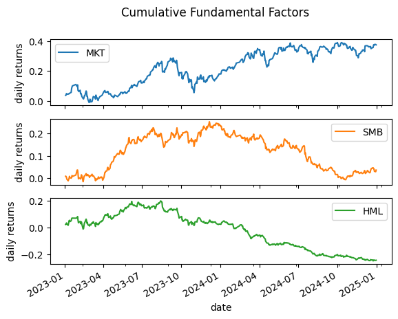

```python
ax = ((F + 1).cumprod() - 1).plot(subplots=True, title='Cumulative Fundamental Factors')
ax[0].set(ylabel = "daily returns")
ax[1].set(ylabel = "daily returns")
ax[2].set(ylabel = "daily returns")
plt.show()
```

### Tính toán các yếu tố rủi ro

Chạy một hồi quy tuyến tính đa biến trên các yếu tố cơ bản cho mỗi tài sản trong danh mục đầu tư, chúng ta có thể thu được các yếu tố rủi ro tương ứng cho mỗi tài sản. Tại đây, chúng ta diễn đạt:

$$ R_i = \alpha_i + \beta_{i, MKT} R_{i, MKT} + \beta_{i, HML} R_{i, HML} + \beta_{i, SMB} R_{i, SMB} + \epsilon_i$$

cho mỗi tài sản $S_i$. Điều này cho chúng ta thấy tỷ lệ phần trăm của lợi nhuận từng chứng khoán được tạo ra từ các yếu tố rủi ro này.

Chúng ta tính toán các yếu tố rủi ro trên từng tài sản để có cái nhìn chi tiết hơn về rủi ro của danh mục đầu tư. Cách tiếp cận này yêu cầu chúng ta biết các khoản đầu tư của danh mục đầu tư trong bất kỳ ngày nào và có chi phí tính toán cao.

```python
# factor exposure
B = pd.DataFrame(index=assets, dtype=np.float32)
```

```python
from IPython.display import clear_output

x = sm.add_constant(F).iloc[1:-1]

all_assets = {}
for i, asset in enumerate(assets):

    print(f"asset {i+1} of {len(assets)}")
    clear_output(wait=True)
    y = R.loc[:, asset].iloc[1:-1]
    y_inlier = y[np.abs(y - y.mean())<=(3*y.std())]
    x_inlier = x[np.abs(y - y.mean())<=(3*y.std())]
    result = sm.OLS(y_inlier, x_inlier).fit()

    B.loc[asset,"MKT_beta"] = result.params.iloc[1]
    B.loc[asset,"SMB_beta"] = result.params.iloc[2]
    B.loc[asset,"HML_beta"] = result.params.iloc[3]
    all_assets[asset] = y - (x.iloc[:,0] * result.params.iloc[0] +
                            x.iloc[:,1] * result.params.iloc[1] +
                            x.iloc[:,2] * result.params.iloc[2] +
                            x.iloc[:,3] * result.params.iloc[3])

epsilon = pd.DataFrame(all_assets, index=R.index, dtype=np.float32)
```

```
asset 100 of 100
```

Các yếu tố tiếp xúc được hiển thị như sau. Mỗi tài sản riêng lẻ trong danh mục của chúng ta sẽ có mức độ tiếp xúc khác nhau với ba yếu tố rủi ro đã được đưa vào.

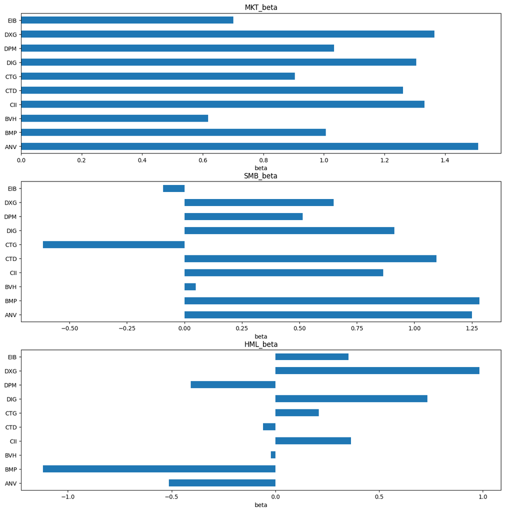

```python
fig,axes = plt.subplots(3, 1)
ax1,ax2,ax3 =axes

B.iloc[0:10,0].plot.barh(ax=ax1, figsize=[15,15], title=B.columns[0])
B.iloc[0:10,1].plot.barh(ax=ax2, figsize=[15,15], title=B.columns[1])
B.iloc[0:10,2].plot.barh(ax=ax3, figsize=[15,15], title=B.columns[2])

ax1.set(xlabel='beta')
ax2.set(xlabel='beta')
ax3.set(xlabel='beta')
plt.show()
```

```python
B.loc['FPT',:]
```

|  | FPT |
| --- | --- |
| MKT_beta | 0.953882 |
| SMB_beta | 0.339294 |
| HML_beta | -0.609709 |

**dtype:** float64

### Tóm tắt về Cách Thiết Lập:

1. Lợi suất của các tài sản trong tập vũ trụ: `R`
2. Các yếu tố cơ bản: `F`
3. Mức độ tiếp xúc của các yếu tố cơ bản này: `B`

Hiện tại, DataFrame `F` chứa các dòng lợi nhuận cho MKT, SMB và HML, được phân loại theo ngày.

```python
F.head(3)
```

| date | MKT | SMB | HML |
| --- | --- | --- | --- |
| 2023-01-03 | 0.037036 | 0.009106 | 0.023702 |
| 2023-01-04 | 0.002216 | -0.000865 | 0.001987 |
| 2023-01-05 | 0.009591 | -0.005012 | 0.008905 |

Trong khi DataFrame `B` chứa các ước lượng điểm của các hệ số beta **đối với** MKT, SMB và HML cho mỗi tài sản trong tập vũ trụ của chúng ta.

```python
B.head(3)
```

|  | MKT_beta | SMB_beta | HML_beta |
| --- | --- | --- | --- |
| ANV | 1.509400 | 1.250127 | -0.513145 |
| BMP | 1.006482 | 1.282053 | -1.120662 |
| BVH | 0.618242 | 0.049799 | -0.020538 |

Bây giờ chúng ta đã có những giá trị này, chúng ta có thể bắt đầu phân tích độ biến động của bất kỳ danh mục đầu tư nào chứa những tài sản này.

### Phân Tích Phương Sai Thành Các Yếu Tố Rủi Ro Chung

Phương sai của danh mục đầu tư có thể được biểu diễn như sau:

$$\sigma^2 = \omega BVB^{\top}\omega^{\top} + \omega D\omega^{\top}$$

Trong đó:

$$\begin{eqnarray} B &=& \text{ma trận thể hiện mức độ tiếp xúc của $n$ tài sản với các yếu tố} \\ V &=& \text{ma trận hiệp phương sai của các yếu tố} \\ D &=& \text{phương sai đặc thù} \\ \omega &=& \text{vector trọng số danh mục cho $n$ tài sản} \\ \omega BVB^{\top}\omega^{\top} &=& \text{phương sai yếu tố chung} \\ \omega D\omega^{\top} &=& \text{phương sai đặc thù} \\ \end{eqnarray}$$

#### Tính Toán Yếu Tố Chung và Phương Sai Đặc Thù:

Chúng ta sẽ xây dựng các hàm để phân tích rủi ro trong danh mục đầu tư của mình. Giả sử rằng danh mục đầu tư của chúng ta bao gồm tất cả các cổ phiếu trong VN100, với trọng số bằng nhau. Hãy cùng xem một cách cụ thể rằng bao nhiêu phần trăm phương sai của lợi suất trong tập vũ trụ này là do yếu tố rủi ro chung.

```python
w = np.ones([1,R.shape[1]])/R.shape[1]
```

```python
def compute_common_factor_variance(factors, factor_exposures, w):
    B = np.asarray(factor_exposures)
    F = np.asarray(factors)
    V = np.asarray(factors.cov())


    return w.dot(B.dot(V).dot(B.T)).dot(w.T)

common_factor_variance = compute_common_factor_variance(F, B, w)[0][0]
print("Common Factor Variance: {0}".format(common_factor_variance))
```

```
Common Factor Variance: 0.0001192952003223721
```

```python
def compute_specific_variance(epsilon, w):

    D = np.diag(np.asarray(epsilon.var())) * epsilon.shape[0] / (epsilon.shape[0]-1)

    return w.dot(D).dot(w.T)

specific_variance = compute_specific_variance(epsilon, w)[0][0]
print("Specific Variance: {0}".format(specific_variance))
```

```
Specific Variance: 2.22583689919702e-06
```

Để tính bao nhiêu phần trăm của phương sai danh mục đầu tư được cấu thành từ yếu tố rủi ro chung, chúng ta thực hiện như sau:

$$\frac{\text{phương sai yếu tố chung}}{\text{phương sai yếu tố chung + phương sai đặc thù}}$$

```python
common_factor_pct = common_factor_variance/(common_factor_variance + specific_variance)*100.0
print("Percentage of Portfolio Variance Due to Common Factor Risk: {0:.2f}%".format(common_factor_pct))
```

```
Percentage of Portfolio Variance Due to Common Factor Risk: 98.17%
```

Vậy chúng ta thấy rằng nếu chúng ta chỉ lấy từng chứng khoán trong VN100 và phân bổ trọng số đều cho chúng, chúng ta sẽ kết thúc với một danh mục đầu tư mà thực chất chỉ chứa rủi ro chung.

### Tối Ưu Hóa Có Giới Hạn Rủi Ro

Hiện tại, chúng ta đang vận hành với một danh mục đầu tư có trọng số bằng nhau. Tuy nhiên, chúng ta có thể phân bổ lại những trọng số đó theo cách tối thiểu hóa rủi ro yếu tố chung được minh họa bởi các mức độ tiếp xúc với yếu tố chung của chúng ta. Đây là một bài toán tối ưu hóa danh mục đầu tư để tìm ra trọng số tối ưu.

Chúng ta định nghĩa bài toán này như sau:

\begin{array}{ll} \mbox{$\text{tối thiểu/tối đa}$}_{w} & \text{hàm mục tiêu}\\ \mbox{với điều kiện} & {\bf 1}^T \omega = 1, \quad f=B^T\omega\\ & \omega \in {\cal W}, \quad f \in {\cal F}, \end{array}

Trong đó, biến $w$ là vector phân bổ, biến $f$ là các mức độ tiếp xúc với yếu tố có trọng số, và biến ${\cal F}$ cung cấp các ràng buộc cho $f$. Chúng ta đặt ${\cal F}$ là một vector để giới hạn các mức độ tiếp xúc với yếu tố có trọng số của danh mục đầu tư. Những ràng buộc này cho phép chúng ta loại bỏ các trọng số không phù hợp với tiêu chí của chúng ta. Ví dụ, chúng ta có thể đặt mức độ tiếp xúc tối đa mà danh mục đầu tư của chúng ta có thể có bằng cách thay đổi giá trị của ${\cal F}$. Một giá trị là $[1,1,1]$ sẽ chỉ ra rằng chúng ta muốn mức độ tiếp xúc tối đa của danh mục đầu tư với mỗi yếu tố phải nhỏ hơn $1$, từ chối bất kỳ danh mục nào không đáp ứng điều kiện đó.

Chúng ta định nghĩa hàm mục tiêu là bất kỳ mục tiêu kinh doanh nào mà chúng ta đánh giá cao nhất. Đây có thể là một cái gì đó như tối đa hóa tỷ lệ Sharpe hoặc tối thiểu hóa độ biến động. Cuối cùng, điều chúng ta muốn giải quyết trong bài toán tối ưu hóa này là các trọng số, $\omega$.

Hãy nhanh chóng tạo một số trọng số ngẫu nhiên để xem cách thay đổi các mức độ tiếp xúc với yếu tố có trọng số của danh mục đầu tư.

```python
w_0 = np.random.rand(R.shape[1])
w_0 = w_0/np.sum(w_0)
```

Biến $f$ chứa các yếu tố tác động có trọng số của danh mục đầu tư của chúng ta, với kích thước bằng số lượng các yếu tố mà chúng ta có. Khi chúng ta thay đổi $\omega$, trọng số của chúng ta, các tác động có trọng số, $f$, cũng thay đổi.

```python
f = B.T.dot(w_0)
f
```

|  | 0 |
| --- | --- |
| MKT_beta | 0.950759 |
| SMB_beta | 0.418174 |
| HML_beta | -0.022020 |

**dtype:** float64

## Tham khảo

- Qian, E.E., Hua, R.H. and Sorensen, E.H., 2007. *Quantitative equity portfolio management: modern techniques and applications*. CRC Press.
- Narang, R.K., 2013. *Inside the Black Box: A Simple Guide to Quantitative and High Frequency Trading*. John Wiley & Sons.

*Lưu ý: Tài liệu này mang tính chất chia sẻ kiến thức khoa học dữ liệu. Các mã chứng khoán xuất hiện trong tài liệu chỉ mang tính chất minh hoạ, không khuyến nghị đầu tư. Chúng tôi không chịu trách nhiệm trước mọi rủi ro nào do sử dụng tài liệu này.*